# Project - Machine Learning

## || Project - Machine Learning ||

### PROBLEM 1:

You are hired by one of the leading news channels CNBE who wants to analyze recent elections. This survey was conducted on 1525 voters with 9 variables. You have to build a model, to predict which party a voter will vote for on the basis of the given information, to create an exit poll that will help in predicting overall win and seats covered by a particular party.

DATA DICTIONARY:

1. vote: Party choice: Conservative or Labour
2. age: in years
3. economic.cond.national: Assessment of current national economic conditions, 1 to 5.
4. economic.cond.household: Assessment of current household economic conditions, 1 to 5.
5. Blair: Assessment of the Labour leader, 1 to 5.
6. Hague: Assessment of the Conservative leader, 1 to 5.
7. Europe: an 11-point scale that measures respondents' attitudes toward European integration. High scores represent ‘Eurosceptic’ sentiment.
8. political.knowledge: Knowledge of parties' positions on European integration, 0 to 3.
9. gender: female or male.

### 1.1 Read the dataset. Do the descriptive statistics and do the null value condition check. Write an inference on it.

#### Importing the Required Libraries and Packages

```python
import numpy as np, pandas as pd, seaborn as sns, matplotlib.pyplot as plt
%matplotlib inline
```

#### Loading the dataset and taking the first column as index

```python
df = pd.read_excel('D:\\SHUBHANK !\\GL\\7. TOPIC 6 - Machine Learning\\Final Project- Machine Learning\\Election_Data.xlsx', index_col=0)
```

#### Checking the Top 10 rows of the Dataset

```python
df.head(10)
```

|  | vote | age | economic.cond.national | economic.cond.household | Blair | Hague | Europe | political.knowledge | gender |
| --- | --- | --- | --- | --- | --- | --- | --- | --- | --- |
| 1 | Labour | 43 | 3 | 3 | 4 | 1 | 2 | 2 | female |
| 2 | Labour | 36 | 4 | 4 | 4 | 4 | 5 | 2 | male |
| 3 | Labour | 35 | 4 | 4 | 5 | 2 | 3 | 2 | male |
| 4 | Labour | 24 | 4 | 2 | 2 | 1 | 4 | 0 | female |
| 5 | Labour | 41 | 2 | 2 | 1 | 1 | 6 | 2 | male |
| 6 | Labour | 47 | 3 | 4 | 4 | 4 | 4 | 2 | male |
| 7 | Labour | 57 | 2 | 2 | 4 | 4 | 11 | 2 | male |
| 8 | Labour | 77 | 3 | 4 | 4 | 1 | 1 | 0 | male |
| 9 | Labour | 39 | 3 | 3 | 4 | 4 | 11 | 0 | female |
| 10 | Labour | 70 | 3 | 2 | 5 | 1 | 11 | 2 | male |

The dataset is loaded properly and the top 10 rows of the dataset are displayed.

As per the given data dictionary, we can also see that the columns 'economic.cond.national' and 'economic.cond.household' are having scales from 1 to 5, so here 1 means low and 5 means good.

#### Checking the 10 rows from the bottom

```python
df.tail(10)
```

|  | vote | age | economic.cond.national | economic.cond.household | Blair | Hague | Europe | political.knowledge | gender |
| --- | --- | --- | --- | --- | --- | --- | --- | --- | --- |
| 1516 | Conservative | 82 | 2 | 2 | 2 | 1 | 11 | 2 | female |
| 1517 | Labour | 30 | 3 | 4 | 4 | 2 | 4 | 2 | male |
| 1518 | Labour | 76 | 4 | 3 | 2 | 2 | 11 | 2 | male |
| 1519 | Labour | 50 | 3 | 4 | 4 | 2 | 5 | 2 | male |
| 1520 | Conservative | 35 | 3 | 4 | 4 | 2 | 8 | 2 | male |
| 1521 | Conservative | 67 | 5 | 3 | 2 | 4 | 11 | 3 | male |
| 1522 | Conservative | 73 | 2 | 2 | 4 | 4 | 8 | 2 | male |
| 1523 | Labour | 37 | 3 | 3 | 5 | 4 | 2 | 2 | male |
| 1524 | Conservative | 61 | 3 | 3 | 1 | 4 | 11 | 2 | male |
| 1525 | Conservative | 74 | 2 | 3 | 2 | 4 | 11 | 0 | female |

The bottom 10 rows of the dataset are displayed.

#### Checking the shape(number of rows and columns) of the Dataset

```python
print('Number of rows:',df.shape[0])
print('Number of columns:',df.shape[1])
```

```
Number of rows: 1525
Number of columns: 9
```

#### Checking all the columns(variables) in the dataset

```python
df.columns
```

```
Index(['vote', 'age', 'economic.cond.national', 'economic.cond.household',
       'Blair', 'Hague', 'Europe', 'political.knowledge', 'gender'],
      dtype='object')
```

#### Checking the data types of all the variables present in the dataset

```python
df.dtypes
```

```
vote                       object
age                         int64
economic.cond.national      int64
economic.cond.household     int64
Blair                       int64
Hague                       int64
Europe                      int64
political.knowledge         int64
gender                     object
dtype: object
```

We can see that only 'vote' and 'gender' has the 'object' data types and all other variables are with 'integer' data types.

#### Describing the dataset

```python
df.describe()
```

|  | age | economic.cond.national | economic.cond.household | Blair | Hague | Europe | political.knowledge |
| --- | --- | --- | --- | --- | --- | --- | --- |
| count | 1525.000000 | 1525.000000 | 1525.000000 | 1525.000000 | 1525.000000 | 1525.000000 | 1525.000000 |
| mean | 54.182295 | 3.245902 | 3.140328 | 3.334426 | 2.746885 | 6.728525 | 1.542295 |
| std | 15.711209 | 0.880969 | 0.929951 | 1.174824 | 1.230703 | 3.297538 | 1.083315 |
| min | 24.000000 | 1.000000 | 1.000000 | 1.000000 | 1.000000 | 1.000000 | 0.000000 |
| 25% | 41.000000 | 3.000000 | 3.000000 | 2.000000 | 2.000000 | 4.000000 | 0.000000 |
| 50% | 53.000000 | 3.000000 | 3.000000 | 4.000000 | 2.000000 | 6.000000 | 2.000000 |
| 75% | 67.000000 | 4.000000 | 4.000000 | 4.000000 | 4.000000 | 10.000000 | 2.000000 |
| max | 93.000000 | 5.000000 | 5.000000 | 5.000000 | 5.000000 | 11.000000 | 3.000000 |

Few Observations based on above description/Summary :

1. We can see that maximum age of the voter is 93 and the minimum age is 24.
2. Mean age is 54.18 and Median age is 53.
3. The standard deviation of the age is much higher than the standard deviation of the other features in the dataset.

#### Checking the Information about the dataset

```python
df.info()
```

```
<class 'pandas.core.frame.DataFrame'>
Int64Index: 1525 entries, 1 to 1525
Data columns (total 9 columns):
 #   Column                   Non-Null Count  Dtype
---  ------                   --------------  -----
 0   vote                     1525 non-null   object
 1   age                      1525 non-null   int64
 2   economic.cond.national   1525 non-null   int64
 3   economic.cond.household  1525 non-null   int64
 4   Blair                    1525 non-null   int64
 5   Hague                    1525 non-null   int64
 6   Europe                   1525 non-null   int64
 7   political.knowledge      1525 non-null   int64
 8   gender                   1525 non-null   object
dtypes: int64(7), object(2)
memory usage: 119.1+ KB
```

#### Checking for the duplicates

```python
dups = df.duplicated()
print('Number of duplicate rows =', dups.sum())
df[dups]
```

```
Number of duplicate rows = 8
```

|  | vote | age | economic.cond.national | economic.cond.household | Blair | Hague | Europe | political.knowledge | gender |
| --- | --- | --- | --- | --- | --- | --- | --- | --- | --- |
| 68 | Labour | 35 | 4 | 4 | 5 | 2 | 3 | 2 | male |
| 627 | Labour | 39 | 3 | 4 | 4 | 2 | 5 | 2 | male |
| 871 | Labour | 38 | 2 | 4 | 2 | 2 | 4 | 3 | male |
| 984 | Conservative | 74 | 4 | 3 | 2 | 4 | 8 | 2 | female |
| 1155 | Conservative | 53 | 3 | 4 | 2 | 2 | 6 | 0 | female |
| 1237 | Labour | 36 | 3 | 3 | 2 | 2 | 6 | 2 | female |
| 1245 | Labour | 29 | 4 | 4 | 4 | 2 | 2 | 2 | female |
| 1439 | Labour | 40 | 4 | 3 | 4 | 2 | 2 | 2 | male |

We found that 8 rows are duplicate in the dataset. Now we will remove them all.

#### Removing all the duplicates

```python
df.drop_duplicates(inplace=True)
```

#### Checking the shape of the dataset after removing the duplicates

```python
print('Number of rows:',df.shape[0])
print('Number of columns:',df.shape[1])
```

```
Number of rows: 1517
Number of columns: 9
```

#### Checking the null values, if present

```python
df.isnull().sum()
```

```
vote                       0
age                        0
economic.cond.national     0
economic.cond.household    0
Blair                      0
Hague                      0
Europe                     0
political.knowledge        0
gender                     0
dtype: int64
```

```python
# Drop the rows with 'nan' values

df = df.dropna()

df.shape
```

```
(1517, 9)
```

```python
df.shape
```

```
(1517, 9)
```

#### Let's check the location of presence of zeros in integer data type columns

```python
df.loc[((df['age'] == 0) | (df['economic.cond.national'] == 0) | (df['economic.cond.household'] == 0) | (df['Blair'] == 0) |
       (df['Hague'] == 0) | (df['Europe'] == 0))]
```

|  | vote | age | economic.cond.national | economic.cond.household | Blair | Hague | Europe | political.knowledge | gender |
| --- | --- | --- | --- | --- | --- | --- | --- | --- | --- |

```python
#Keeping the Original dataset safe, so copying

original_data = df.copy()
```

### 1.2 Perform Univariate and Bivariate Analysis. Do exploratory data analysis. Check for Outliers.

#### Let's check the value counts of 'vote' and 'gender' variable

```python
df['vote'].value_counts()
```

```
Labour          1057
Conservative     460
Name: vote, dtype: int64
```

```python
#percentage count

df.vote.value_counts(normalize=True)
```

```
Labour          0.69677
Conservative    0.30323
Name: vote, dtype: float64
```

We can see from the above value_counts that 'Labour' party has the more number of counts than 'Conservative' party.

```python
df['gender'].value_counts()
```

```
female    808
male      709
Name: gender, dtype: int64
```

```python
#percentage count

df.gender.value_counts(normalize=True)
```

```
female    0.53263
male      0.46737
Name: gender, dtype: float64
```

We can see that the female voters are more in count than the male voters.

### Univariate and Bivariate Analysis

#### Histogram

```
array([[<AxesSubplot:title={'center':'age'}>,
        <AxesSubplot:title={'center':'economic.cond.national'}>,
        <AxesSubplot:title={'center':'economic.cond.household'}>],
       [<AxesSubplot:title={'center':'Blair'}>,
        <AxesSubplot:title={'center':'Hague'}>,
        <AxesSubplot:title={'center':'Europe'}>],
       [<AxesSubplot:title={'center':'political.knowledge'}>,
        <AxesSubplot:>, <AxesSubplot:>]], dtype=object)
```

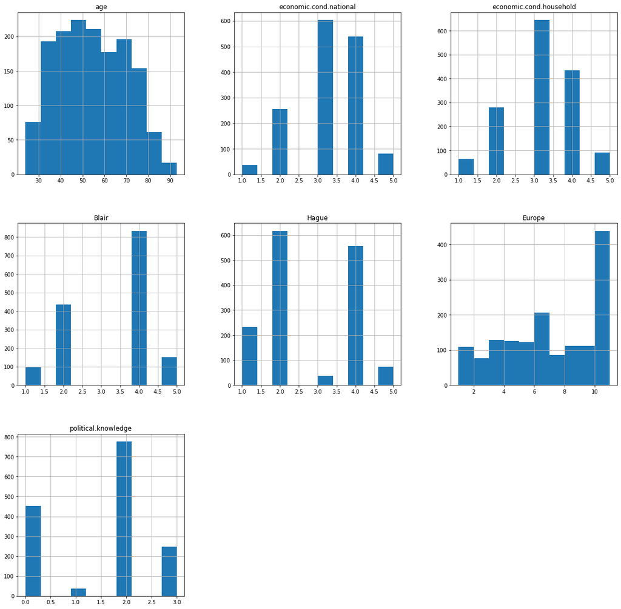

```python
df.hist(figsize=(20,20))
```

#### Distribution Plot to show the distribution of the continuous variables

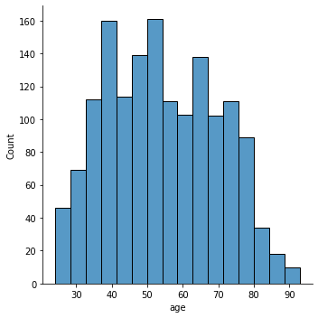

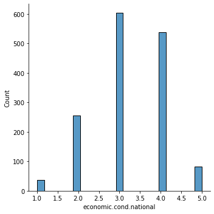

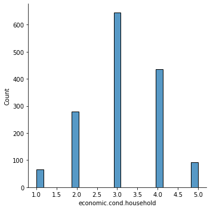

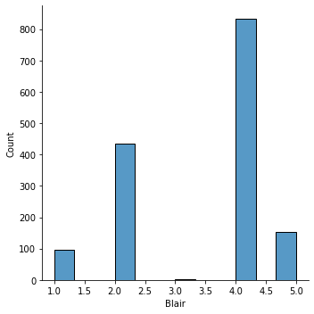

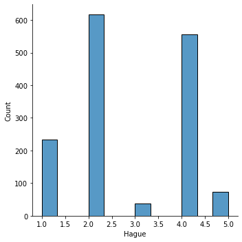

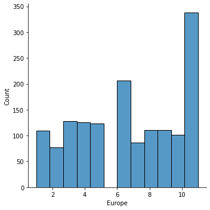

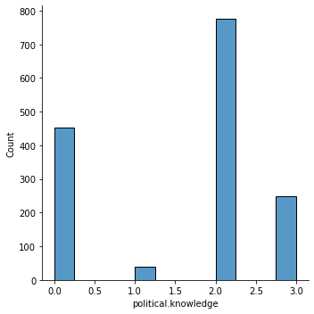

```python
num_columns = ['age', 'economic.cond.national', 'economic.cond.household',
       'Blair', 'Hague', 'Europe', 'political.knowledge']

for i in num_columns:
    plt.figure()
    sns.displot(df[i])
    plt.show()
```

#### Boxplot to show outliers

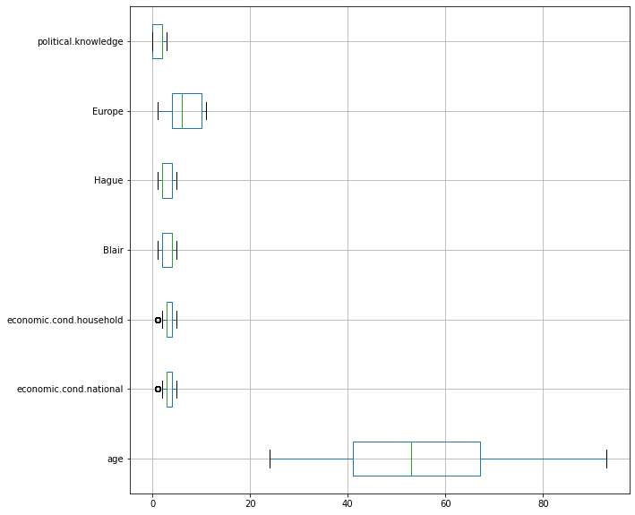

```python
plt.figure(figsize=(10,10))
df.boxplot(vert=0)
plt.show()
```

Plot is showing that very few Outliers are present in 'economic.cond.national' and 'economic.cond.household', and these are ratings or scale, so we can ignore and choose not to remove those outliers.

#### Pairplot

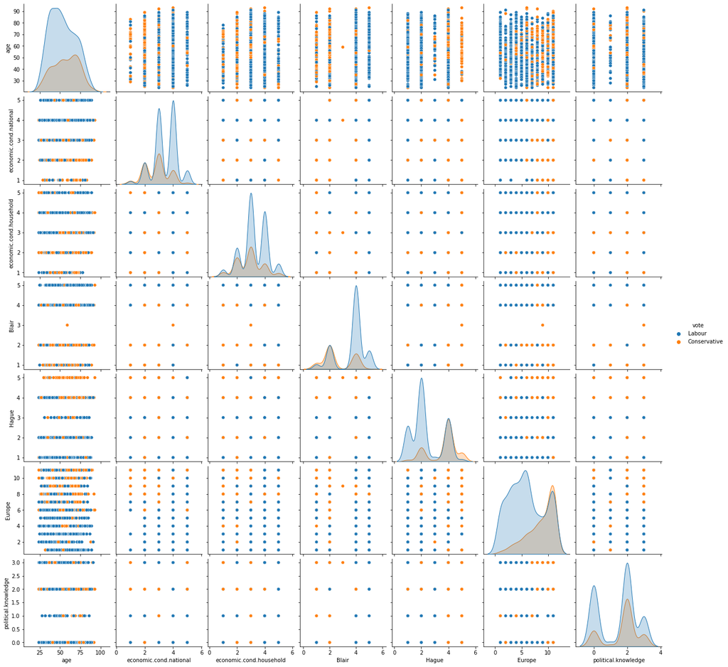

```python
sns.pairplot(df, hue='vote')
```

#### Heatmap

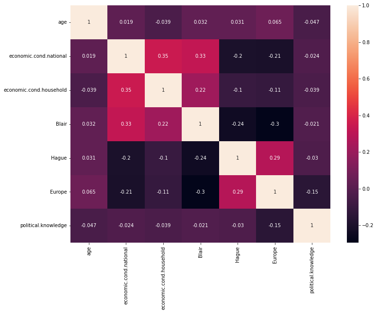

```python
plt.figure(figsize=(12,9))
sns.heatmap(df.corr(),annot=True)
```

There isn't very high correlation between any two variables.

#### Barplot

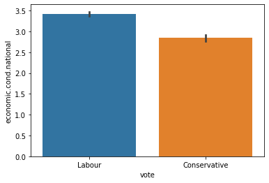

```python
sns.barplot(data = df, x='vote',y='economic.cond.national')
```

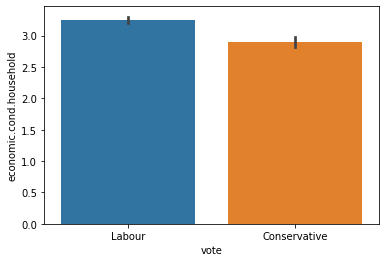

```python
sns.barplot(data = df, x='vote',y='economic.cond.household')
```

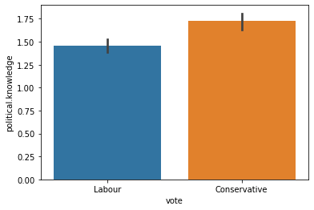

```python
sns.barplot(data = df, x='vote',y='political.knowledge')
```

#### Countplots

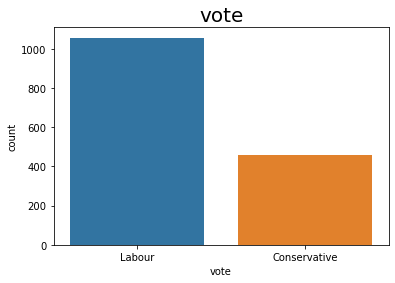

```python
sns.countplot(data = df, x = df.vote)
plt.title('vote', fontsize=20)
plt.show()
```

We can see from the above countplot that Labour party gets more than 1000+ votes, which is much better than the vote counts of the Conservative party.

#### Checking categorical columns and numerical columns, so that the further calculations would we easy

```python
obj_cols=[]
int_cols=[]

for i in df.columns:
    if df[i].dtype=="object":
        obj_cols.append(i)
    else:
        int_cols.append(i)

print('Columns with Object datatype:\n',obj_cols)

print('Columns with Integer datatype:\n',int_cols)
```

```
Columns with Object datatype:
 ['vote', 'gender']
Columns with Integer datatype:
 ['age', 'economic.cond.national', 'economic.cond.household', 'Blair', 'Hague', 'Europe', 'political.knowledge']
```

We can see that python is treating categorical columns as numerical columns. But we know that except 'age' column, all other columns are categorical in nature. So, first we need to educate python that the columns like 'economic.cond.national', 'economic.cond.household', 'Blair', 'Hague', 'Europe', 'political.knowledge' and 'gender' are to be treated as categorical columns.

We will do this by type conversion.

```python
#using df.astype

df = df.astype({'vote':'category','economic.cond.national':'category', 'economic.cond.household':'category', 'Blair':'category', 'Hague':'category', 'Europe':'category', 'political.knowledge':'category','gender':'category'})


# Now print the data type of all columns after change
df.info()
```

```
<class 'pandas.core.frame.DataFrame'>
Int64Index: 1517 entries, 1 to 1525
Data columns (total 9 columns):
 #   Column                   Non-Null Count  Dtype
---  ------                   --------------  -----
 0   vote                     1517 non-null   category
 1   age                      1517 non-null   int64
 2   economic.cond.national   1517 non-null   category
 3   economic.cond.household  1517 non-null   category
 4   Blair                    1517 non-null   category
 5   Hague                    1517 non-null   category
 6   Europe                   1517 non-null   category
 7   political.knowledge      1517 non-null   category
 8   gender                   1517 non-null   category
dtypes: category(8), int64(1)
memory usage: 69.5 KB
```

### 1.3 Encode the data (having string values) for Modeling. Is Scaling necessary here or not? Data Split: Split the data into train and test (70:30)

```python
cat_col = ['vote','gender']
```

```python
#Applying pd.get_dummies on cat_col

df =pd.get_dummies(df, columns=cat_col ,drop_first=True)
```

```python
df.head()
```

|  | age | economic.cond.national | economic.cond.household | Blair | Hague | Europe | political.knowledge | vote_Labour | gender_male |
| --- | --- | --- | --- | --- | --- | --- | --- | --- | --- |
| 1 | 43 | 3 | 3 | 4 | 1 | 2 | 2 | 1 | 0 |
| 2 | 36 | 4 | 4 | 4 | 4 | 5 | 2 | 1 | 1 |
| 3 | 35 | 4 | 4 | 5 | 2 | 3 | 2 | 1 | 1 |
| 4 | 24 | 4 | 2 | 2 | 1 | 4 | 0 | 1 | 0 |
| 5 | 41 | 2 | 2 | 1 | 1 | 6 | 2 | 1 | 1 |

```python
#keeping this df safe

df1 = df.copy()

dfcopy = df1.copy()
```

```python
#Now, let's separate dependent and independent variables

X = df.drop('vote_Labour', axis=1)
Y = df[['vote_Labour']]
```

```python
X.head()
```

|  | age | economic.cond.national | economic.cond.household | Blair | Hague | Europe | political.knowledge | gender_male |
| --- | --- | --- | --- | --- | --- | --- | --- | --- |
| 1 | 43 | 3 | 3 | 4 | 1 | 2 | 2 | 0 |
| 2 | 36 | 4 | 4 | 4 | 4 | 5 | 2 | 1 |
| 3 | 35 | 4 | 4 | 5 | 2 | 3 | 2 | 1 |
| 4 | 24 | 4 | 2 | 2 | 1 | 4 | 0 | 0 |
| 5 | 41 | 2 | 2 | 1 | 1 | 6 | 2 | 1 |

#### Scaling of the data

Scaling of the data comes under the set of steps of data pre-processing when we are performing machine learning algorithms in the data set. Data standardization is the process of rescaling the attributes so that they have mean as 0 and variance as 1. The ultimate goal to perform standardization is to bring down all the features to a common scale without distorting the differences in the range of the values.

To bring all features in the same standing, we need to do scaling so that one significant number does not impact the model just because of their large magnitude.

Features scaling is necessary for this dataset, because we have seen in the boxplot that the 'age' feature has the numeric values which are much greater than the values present in the other features of the dataset.

Also we found out from the description(describe function) of the dataset that standard deviation of the 'age' is much higher than the standard deviation of the other available features in the dataset.

```python
#Using standard scaler:

from sklearn.preprocessing import StandardScaler

scaler = StandardScaler()

scaler.fit(X) #we will use scaled_df for the models that gets affected without feature scaling
```

```
StandardScaler()
```

```python
X.head()
```

|  | age | economic.cond.national | economic.cond.household | Blair | Hague | Europe | political.knowledge | gender_male |
| --- | --- | --- | --- | --- | --- | --- | --- | --- |
| 1 | 43 | 3 | 3 | 4 | 1 | 2 | 2 | 0 |
| 2 | 36 | 4 | 4 | 4 | 4 | 5 | 2 | 1 |
| 3 | 35 | 4 | 4 | 5 | 2 | 3 | 2 | 1 |
| 4 | 24 | 4 | 2 | 2 | 1 | 4 | 0 | 0 |
| 5 | 41 | 2 | 2 | 1 | 1 | 6 | 2 | 1 |

#### Split the data into train and test set in 70:30 ratio

```python
from sklearn.model_selection import train_test_split

X_train, X_test, Y_train, Y_test = train_test_split(X, Y, test_size=0.3 , random_state=1)
```

```python
X_train.head()
```

|  | age | economic.cond.national | economic.cond.household | Blair | Hague | Europe | political.knowledge | gender_male |
| --- | --- | --- | --- | --- | --- | --- | --- | --- |
| 992 | 34 | 2 | 4 | 1 | 4 | 11 | 2 | 0 |
| 1275 | 40 | 4 | 3 | 4 | 4 | 6 | 0 | 1 |
| 650 | 61 | 4 | 3 | 4 | 4 | 7 | 2 | 0 |
| 678 | 47 | 3 | 3 | 4 | 2 | 11 | 0 | 1 |
| 539 | 44 | 5 | 3 | 4 | 2 | 8 | 0 | 1 |

```python
scaler.fit_transform(X_test)
X_test.head()
```

|  | age | economic.cond.national | economic.cond.household | Blair | Hague | Europe | political.knowledge | gender_male |
| --- | --- | --- | --- | --- | --- | --- | --- | --- |
| 505 | 71 | 3 | 3 | 2 | 2 | 8 | 2 | 0 |
| 370 | 43 | 3 | 2 | 4 | 2 | 8 | 3 | 1 |
| 1076 | 89 | 5 | 5 | 5 | 2 | 1 | 2 | 1 |
| 1032 | 47 | 2 | 3 | 2 | 4 | 8 | 2 | 0 |
| 1330 | 33 | 5 | 4 | 4 | 4 | 8 | 0 | 1 |

### 1.4. Apply Logistic Regression and LDA (linear discriminant analysis).

### Logistic Regression

```python
#We will use GridSearchCV for getting the best parameters for the model

from sklearn.model_selection import GridSearchCV

grid={'penalty':['l1','l2','none'], 'solver':['lbfgs', 'liblinear'], 'tol':[0.0001,0.000001]}
```

```python
# Fit the Logistic Regression model

from sklearn.linear_model import LogisticRegression

model = LogisticRegression(max_iter=100000,n_jobs=2)

grid_search = GridSearchCV(estimator = model, param_grid = grid, cv = 3,n_jobs=-1,scoring='f1')
```

```python
grid_search.fit(X_train, Y_train)
```

```
GridSearchCV(cv=3, estimator=LogisticRegression(max_iter=100000, n_jobs=2),
             n_jobs=-1,
             param_grid={'penalty': ['l1', 'l2', 'none'],
                         'solver': ['lbfgs', 'liblinear'],
                         'tol': [0.0001, 1e-06]},
             scoring='f1')
```

```python
#Getting the best parameters and best grid estimators:

grid_search.best_params_
```

```
{'penalty': 'l2', 'solver': 'liblinear', 'tol': 0.0001}
```

```python
best_model = grid_search.best_estimator_
best_model
```

```
LogisticRegression(max_iter=100000, n_jobs=2, solver='liblinear')
```

### Predicting on Training and Test dataset

```python
ytrain_predict = best_model.predict(X_train)
ytest_predict = best_model.predict(X_test)
```

```python
## Getting the probabilities on the test set

ytest_predict_prob = best_model.predict_proba(X_test)
```

```python
#Checking the head from the predicted probability

pd.DataFrame(ytest_predict_prob).head(10)
```

|  | 0 | 1 |
| --- | --- | --- |
| 0 | 0.427675 | 0.572325 |
| 1 | 0.155830 | 0.844170 |
| 2 | 0.006244 | 0.993756 |
| 3 | 0.842250 | 0.157750 |
| 4 | 0.066400 | 0.933600 |
| 5 | 0.062857 | 0.937143 |
| 6 | 0.349056 | 0.650944 |
| 7 | 0.230190 | 0.769810 |
| 8 | 0.043898 | 0.956102 |
| 9 | 0.137002 | 0.862998 |

### Confusion Matrix and Classification Report on the Training Data

```
<sklearn.metrics._plot.confusion_matrix.ConfusionMatrixDisplay at 0x13fecfa7a30>
```

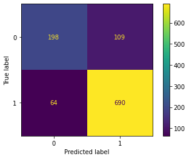

```python
## Confusion matrix on the training data

from sklearn import metrics
from sklearn.metrics import roc_auc_score,roc_curve,classification_report,confusion_matrix,plot_confusion_matrix

plot_confusion_matrix(best_model,X_train,Y_train)
```

```python
print(classification_report(Y_train, ytrain_predict))
```

```
              precision    recall  f1-score   support

           0       0.76      0.64      0.70       307
           1       0.86      0.92      0.89       754

    accuracy                           0.84      1061
   macro avg       0.81      0.78      0.79      1061
weighted avg       0.83      0.84      0.83      1061
```

### Confusion Matrix and Classification Report on Testing Data

```
<sklearn.metrics._plot.confusion_matrix.ConfusionMatrixDisplay at 0x13fed262130>
```

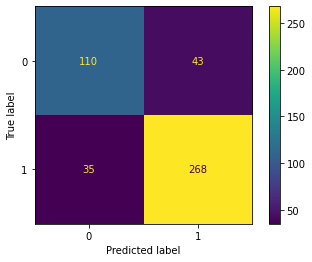

```python
## Confusion matrix on the test data

plot_confusion_matrix(best_model,X_test,Y_test)
```

```python
print(classification_report(Y_test, ytest_predict))
```

```
              precision    recall  f1-score   support

           0       0.76      0.72      0.74       153
           1       0.86      0.88      0.87       303

    accuracy                           0.83       456
   macro avg       0.81      0.80      0.81       456
weighted avg       0.83      0.83      0.83       456
```

### Conclusion

The recall and f1 score also good in case of training data.

### Model Evaluation

```python
# Accuracy score for training data

acc_train = best_model.score(X_train, Y_train)

acc_train
```

```
0.8369462770970783
```

### AUC and ROC for the training data

```python
# predict probabilities

probs = best_model.predict_proba(X_train)
```

```python
# keep probabilities for the positive outcome only

probs = probs[:, 1]
```

```python
# calculate AUC
auc = roc_auc_score(Y_train, probs)
print('AUC: %.3f' % auc)
```

```
AUC: 0.890
```

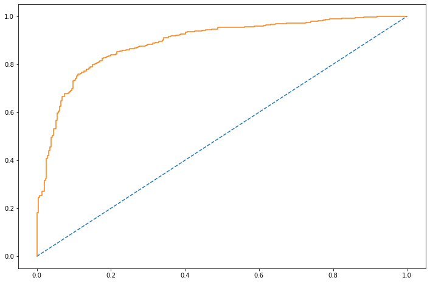

```python
# calculate roc curve

train_fpr, train_tpr, train_thresholds = roc_curve(Y_train, probs)
plt.rcParams["figure.figsize"] = (12,8)
plt.plot([0, 1], [0, 1], linestyle='--')
# plot the roc curve for the model
plt.plot(train_fpr, train_tpr);
```

```python
#Accuracy score for test data

acc_test = best_model.score(X_test, Y_test)

acc_test
```

```
0.8289473684210527
```

```
AUC: 0.880
```

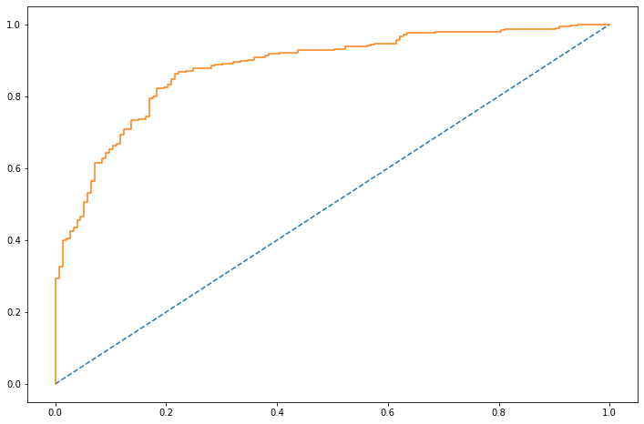

```python
# predict probabilities
probs = best_model.predict_proba(X_test)

# Probabilities for the positive outcome only
probs = probs[:, 1]

# calculate AUC
test_auc = roc_auc_score(Y_test, probs)
print('AUC: %.3f' % test_auc)

# calculate roc curve
test_fpr, test_tpr, test_thresholds = roc_curve(Y_test, probs)
plt.plot([0, 1], [0, 1], linestyle='--')

# plot the roc curve for the model
plt.plot(test_fpr, test_tpr);
```

### Linear Discriminant Analysis (LDA)

```python
from sklearn.discriminant_analysis import LinearDiscriminantAnalysis
from sklearn import metrics, model_selection
from sklearn.preprocessing import scale

x = df1.drop('vote_Labour',axis=1)
y = df1.pop('vote_Labour')
```

```python
from sklearn.model_selection import train_test_split,GridSearchCV

x_train,x_test,y_train,y_test = train_test_split(x,y,test_size=0.20,random_state=1,stratify = y)
```

```python
clf = LinearDiscriminantAnalysis()

LDA_model=clf.fit(x_train,y_train)
```

```python
#Train data class prediction
#cut off value is 0.5

pred_class_train = LDA_model.predict(x_train)
```

```python
# Test data class prediction
#cut-off value is 0.5

pred_class_test = LDA_model.predict(x_test)
```

```python
print('Classification Report of the training data:\n\n',metrics.classification_report(y_train,pred_class_train),'\n')
print('Classification Report of the test data:\n\n',metrics.classification_report(y_test,pred_class_test),'\n')
```

```
Classification Report of the training data:

               precision    recall  f1-score   support

           0       0.74      0.68      0.71       368
           1       0.86      0.90      0.88       845

    accuracy                           0.83      1213
   macro avg       0.80      0.79      0.79      1213
weighted avg       0.83      0.83      0.83      1213


Classification Report of the test data:

               precision    recall  f1-score   support

           0       0.80      0.72      0.75        92
           1       0.88      0.92      0.90       212

    accuracy                           0.86       304
   macro avg       0.84      0.82      0.83       304
weighted avg       0.86      0.86      0.86       304
```

### Probability prediction for the training and test data

```python
# Training Data Probability Prediction
pred_prob_train = LDA_model.predict_proba(x_train)

# Test Data Probability Prediction
pred_prob_test = LDA_model.predict_proba(x_test)
```

### AUC and ROC for the training data

```
AUC for the Training Data: 0.880
AUC for the Test Data: 0.921
```

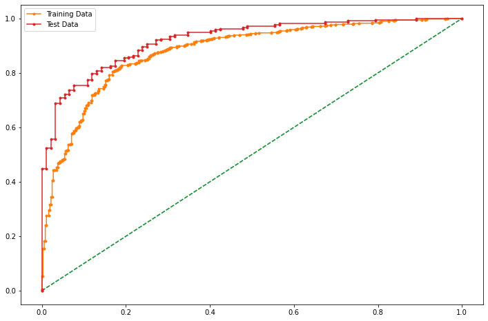

```python
# calculate AUC
auc = metrics.roc_auc_score(y_train,pred_prob_train[:,1])
print('AUC for the Training Data: %.3f' % auc)

#  calculate roc curve
fpr, tpr, thresholds = metrics.roc_curve(y_train,pred_prob_train[:,1])
plt.plot([0, 1], [0, 1], linestyle='--')
# plot the roc curve for the model
plt.plot(fpr, tpr, marker='.',label = 'Training Data')


# AUC and ROC for the test data

# calculate AUC
auc = metrics.roc_auc_score(y_test,pred_prob_test[:,1])
print('AUC for the Test Data: %.3f' % auc)

#  calculate roc curve
fpr, tpr, thresholds = metrics.roc_curve(y_test,pred_prob_test[:,1])
plt.plot([0, 1], [0, 1], linestyle='--')
# plot the roc curve for the model
plt.plot(fpr, tpr, marker='.',label='Test Data')
# show the plot
plt.legend(loc='best')
plt.show()
```

### Conclusion

The accuracy of the model for the train data is 83% and for the testing data is 86%.

recall and f1 score is also pretty good in testing data.

### 1.5 Apply KNN Model and Naïve Bayes Model. Interpret the results.

### KNN Model

```python
from scipy.stats import zscore
```

```python
X[['age','economic.cond.national','economic.cond.household','Blair','Hague','Europe','political.knowledge','gender_male']]=x[['age','economic.cond.national','economic.cond.household','Blair','Hague','Europe','political.knowledge','gender_male']].apply(zscore)
```

```python
X.head()
```

|  | age | economic.cond.national | economic.cond.household | Blair | Hague | Europe | political.knowledge | gender_male |
| --- | --- | --- | --- | --- | --- | --- | --- | --- |
| 1 | -0.716161 | -0.278185 | -0.148020 | 0.565802 | -1.419969 | -1.437338 | 0.423832 | -0.936736 |
| 2 | -1.162118 | 0.856242 | 0.926367 | 0.565802 | 1.014951 | -0.527684 | 0.423832 | 1.067536 |
| 3 | -1.225827 | 0.856242 | 0.926367 | 1.417312 | -0.608329 | -1.134120 | 0.423832 | 1.067536 |
| 4 | -1.926617 | 0.856242 | -1.222408 | -1.137217 | -1.419969 | -0.830902 | -1.421084 | -0.936736 |
| 5 | -0.843577 | -1.412613 | -1.222408 | -1.988727 | -1.419969 | -0.224465 | 0.423832 | 1.067536 |

```python
#Now we will split the data into train and test set for KNN model

from sklearn.model_selection import train_test_split

X_train,X_test,Y_train,Y_test=train_test_split(X,Y, random_state=1)
```

```python
#Now lets import KNeighboursClassifier

from sklearn.neighbors import KNeighborsClassifier

KNN_model = KNeighborsClassifier()

KNN_model.fit(X_train,Y_train)
```

```
KNeighborsClassifier()
```

```python
#let's predict the model on X_train and check the model score

predicted_labels = KNN_model.predict(X_train)

KNN_model_score = KNN_model.score(X_train,Y_train)
```

```python
#model score

print(KNN_model_score)
```

```
0.8566402814423922
```

### Confusion mAtrix and Classification Report

```python
print('Confusion Matrix\n')

print(metrics.confusion_matrix(Y_train,predicted_labels))

print('Classification Report\n')

print(metrics.classification_report(Y_train,predicted_labels))
```

```
Confusion Matrix

[[232  95]
 [ 68 742]]
Classification Report

              precision    recall  f1-score   support

           0       0.77      0.71      0.74       327
           1       0.89      0.92      0.90       810

    accuracy                           0.86      1137
   macro avg       0.83      0.81      0.82      1137
weighted avg       0.85      0.86      0.85      1137
```

```
auc 0.929
```

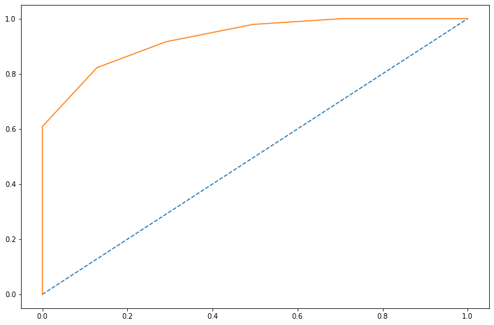

```python
### AUC ROC Curve on Train data

probs_train=KNN_model.predict_proba(X_train)
probs_train=probs_train[:, 1]
auc=roc_auc_score(Y_train,probs_train)
print("auc %.3f " % auc)
train_fpr ,train_tpr, train_thresholds= roc_curve(Y_train,probs_train)
plt.plot([0,1],[0,1],linestyle='--')
plt.plot(train_fpr,train_tpr);
```

### Naive Bayes Model

```python
df.head()
```

|  | age | economic.cond.national | economic.cond.household | Blair | Hague | Europe | political.knowledge | vote_Labour | gender_male |
| --- | --- | --- | --- | --- | --- | --- | --- | --- | --- |
| 1 | 43 | 3 | 3 | 4 | 1 | 2 | 2 | 1 | 0 |
| 2 | 36 | 4 | 4 | 4 | 4 | 5 | 2 | 1 | 1 |
| 3 | 35 | 4 | 4 | 5 | 2 | 3 | 2 | 1 | 1 |
| 4 | 24 | 4 | 2 | 2 | 1 | 4 | 0 | 1 | 0 |
| 5 | 41 | 2 | 2 | 1 | 1 | 6 | 2 | 1 | 1 |

```python
#Let's first separate the independent and depedent variables from the saved dataset that is df1

X = df.drop('vote_Labour',axis=1)

Y = df['vote_Labour']

x_train, x_test, y_train, y_test = train_test_split(X, Y, test_size=0.3, random_state=1)

x_train.head()
```

|  | age | economic.cond.national | economic.cond.household | Blair | Hague | Europe | political.knowledge | gender_male |
| --- | --- | --- | --- | --- | --- | --- | --- | --- |
| 992 | 34 | 2 | 4 | 1 | 4 | 11 | 2 | 0 |
| 1275 | 40 | 4 | 3 | 4 | 4 | 6 | 0 | 1 |
| 650 | 61 | 4 | 3 | 4 | 4 | 7 | 2 | 0 |
| 678 | 47 | 3 | 3 | 4 | 2 | 11 | 0 | 1 |
| 539 | 44 | 5 | 3 | 4 | 2 | 8 | 0 | 1 |

### Train Naive Bayes algorithm

```python
from sklearn.naive_bayes import GaussianNB # using Gaussian algorithm from Naive Bayes

# create the model

nb_model = GaussianNB()

nb_model.fit(x_train, y_train.ravel())
```

```
GaussianNB()
```

### Let see the performance of our model with training data

```python
nb_train_predict = nb_model.predict(x_train)

from sklearn import metrics

print("Model Accuracy: {0:.2f}".format(metrics.accuracy_score(y_train, nb_train_predict)))
```

```
Model Accuracy: 0.84
```

### Now let see the performance of our model with testing data

```python
nb_test_predict = nb_model.predict(x_test)

from sklearn import metrics

print("Model Accuracy: {0:.2f}".format(metrics.accuracy_score(y_test, nb_test_predict)))
```

```
Model Accuracy: 0.82
```

### Confusion Matrix and Classification Report

```
Confusion Matrix:
```

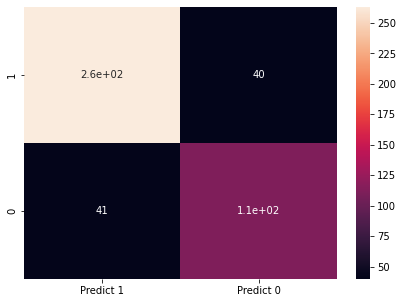

```python
print("Confusion Matrix:\n")

cm = metrics.confusion_matrix(y_test, nb_test_predict, labels=[1, 0])

df_cm = pd.DataFrame(cm, index = [i for i in ["1","0"]],
                  columns = [i for i in ["Predict 1","Predict 0"]])
plt.figure(figsize = (7,5))
sns.heatmap(df_cm, annot=True)
```

```python
print("Classification Report")
print(metrics.classification_report(y_test, nb_test_predict, labels=[1, 0]))
```

```
Classification Report
              precision    recall  f1-score   support

           1       0.87      0.87      0.87       303
           0       0.74      0.73      0.73       153

    accuracy                           0.82       456
   macro avg       0.80      0.80      0.80       456
weighted avg       0.82      0.82      0.82       456
```

The precision for 1 is above 80% and accuracy is also above 80%

### 1.6 Model Tuning, Bagging (Random Forest should be applied for Bagging), and Boosting.

```python
#We will use Random forest for Bagging
#let's first import RandomForestClassifier from sklearn.ensemble

from sklearn.ensemble import RandomForestClassifier
```

```python
#we will take the copied df that is original_data for building Random Forest
#because as we know that Random Forest is not affected by feature scaling

dfcopy.head()
```

|  | age | economic.cond.national | economic.cond.household | Blair | Hague | Europe | political.knowledge | vote_Labour | gender_male |
| --- | --- | --- | --- | --- | --- | --- | --- | --- | --- |
| 1 | 43 | 3 | 3 | 4 | 1 | 2 | 2 | 1 | 0 |
| 2 | 36 | 4 | 4 | 4 | 4 | 5 | 2 | 1 | 1 |
| 3 | 35 | 4 | 4 | 5 | 2 | 3 | 2 | 1 | 1 |
| 4 | 24 | 4 | 2 | 2 | 1 | 4 | 0 | 1 | 0 |
| 5 | 41 | 2 | 2 | 1 | 1 | 6 | 2 | 1 | 1 |

```python
dfcopy.info()
```

```
<class 'pandas.core.frame.DataFrame'>
Int64Index: 1517 entries, 1 to 1525
Data columns (total 9 columns):
 #   Column                   Non-Null Count  Dtype
---  ------                   --------------  -----
 0   age                      1517 non-null   int64
 1   economic.cond.national   1517 non-null   category
 2   economic.cond.household  1517 non-null   category
 3   Blair                    1517 non-null   category
 4   Hague                    1517 non-null   category
 5   Europe                   1517 non-null   category
 6   political.knowledge      1517 non-null   category
 7   vote_Labour              1517 non-null   uint8
 8   gender_male              1517 non-null   uint8
dtypes: category(6), int64(1), uint8(2)
memory usage: 69.2 KB
```

```python
dfcopy = dfcopy.astype({'economic.cond.national':'category', 'economic.cond.household':'category', 'Blair':'category', 'Hague':'category', 'Europe':'category', 'political.knowledge':'category','vote_Labour':'category','gender_male':'category'})
```

```python
dfcopy.info()
```

```
<class 'pandas.core.frame.DataFrame'>
Int64Index: 1517 entries, 1 to 1525
Data columns (total 9 columns):
 #   Column                   Non-Null Count  Dtype
---  ------                   --------------  -----
 0   age                      1517 non-null   int64
 1   economic.cond.national   1517 non-null   category
 2   economic.cond.household  1517 non-null   category
 3   Blair                    1517 non-null   category
 4   Hague                    1517 non-null   category
 5   Europe                   1517 non-null   category
 6   political.knowledge      1517 non-null   category
 7   vote_Labour              1517 non-null   category
 8   gender_male              1517 non-null   category
dtypes: category(8), int64(1)
memory usage: 69.5 KB
```

```python
X = dfcopy.drop("vote_Labour" , axis=1)
y = dfcopy.pop("vote_Labour")
```

```python
X_train, X_test, y_train, y_test = train_test_split(X, y, test_size=.30, random_state=1)
```

### Now Let's Build RandomForest

```python
rfcl = RandomForestClassifier(n_estimators=301, oob_score = True, max_depth = 10, max_features = 5, min_samples_leaf = 50, min_samples_split=110)

rfcl = rfcl.fit(X_train, y_train)
```

NOTE:

n_estimators is the number of trees, that we want to build within the RandomForestClassifier. Out of bag (OOB) score is a way of validating the Random forest model. OOB score is computed as the number of correctly predicted rows from the out of bag sample. max_features will be used to select randomly features from the available number of features.

```python
rfcl
```

```
RandomForestClassifier(max_depth=10, max_features=5, min_samples_leaf=50,
                       min_samples_split=110, n_estimators=301, oob_score=True)
```

```python
rfcl.oob_score_
```

```
0.823751178133836
```

```python
#Checking the error rate in %:

print('error_rate(in %) :', 1- (rfcl.oob_score_))

#NOTE: OOB Error is the number of wrongly classifying the OOB Sample.
```

```
error_rate(in %) : 0.17624882186616397
```

### Getting the Feature Importances

```python
print (pd.DataFrame(rfcl.feature_importances_, columns = ["Imp"],
                    index = X_train.columns).sort_values('Imp',ascending=False))
```

```
                              Imp
Hague                    0.406048
Blair                    0.302594
Europe                   0.205316
economic.cond.national   0.038313
political.knowledge      0.021143
age                      0.019404
economic.cond.household  0.005826
gender_male              0.001356
```

### Let's Now use Ensemble Learning methods and see the result

#### We will use Bagging , Ada Boosting and GradientBoost

#### Let's first look by use Bagging:

```python
#First import BaggingClassifier from sklearn.ensemble

#we will be using random forest as base_estimator

from sklearn.ensemble import BaggingClassifier

bgcl = BaggingClassifier(base_estimator=rfcl, n_estimators=50,random_state=1)
#bgcl = BaggingClassifier(n_estimators=50,random_state=1)

bgcl = bgcl.fit(X_train, y_train)
```

```
0.7807017543859649
```

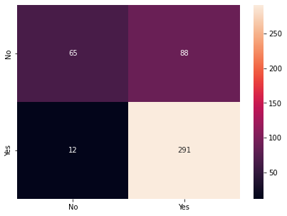

```python
y_predict = bgcl.predict(X_test)

print(bgcl.score(X_test , y_test))

cm=metrics.confusion_matrix(y_test, y_predict,labels=[0, 1])

df_cm = pd.DataFrame(cm, index = [i for i in ["No","Yes"]],
                  columns = [i for i in ["No","Yes"]])
plt.figure(figsize = (7,5))
sns.heatmap(df_cm, annot=True ,fmt='g')
```

#### Ada Boosting

```python
#first importing AdaBoostClassifier from sklearn.ensemble

from sklearn.ensemble import AdaBoostClassifier

abcl = AdaBoostClassifier(n_estimators=10, random_state=1)

#Applying .fit to the train data
abcl = abcl.fit(X_train, y_train)
```

```
0.8201754385964912
```

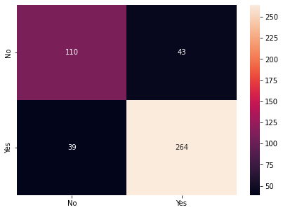

```python
y_predict = abcl.predict(X_test)
print(abcl.score(X_test , y_test))

cm=metrics.confusion_matrix(y_test, y_predict,labels=[0, 1])

df_cm = pd.DataFrame(cm, index = [i for i in ["No","Yes"]],
                  columns = [i for i in ["No","Yes"]])
plt.figure(figsize = (7,5))
sns.heatmap(df_cm, annot=True ,fmt='g')
```

#### GradientBoost

```python
from sklearn.ensemble import GradientBoostingClassifier
gbcl = GradientBoostingClassifier(n_estimators = 50,random_state=1)
gbcl = gbcl.fit(X_train, y_train)
```

```
0.8289473684210527
```

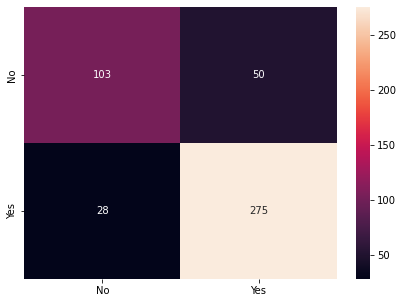

```python
y_predict = gbcl.predict(X_test)
print(gbcl.score(X_test, y_test))
cm=metrics.confusion_matrix(y_test, y_predict,labels=[0, 1])

df_cm = pd.DataFrame(cm, index = [i for i in ["No","Yes"]],
                  columns = [i for i in ["No","Yes"]])
plt.figure(figsize = (7,5))
sns.heatmap(df_cm, annot=True ,fmt='g')
```

### 1.7 Performance Metrics: Check the performance of Predictions on Train and Test sets using Accuracy, Confusion Matrix, Plot ROC curve and get ROC_AUC score for each model. Final Model: Compare the models and write inference which model is best/optimized. (7 marks)